# Machine Learning :: R Extensibility Instructions

- Pre-extensibility checks
- Installing the Extensibility Packages
- Permissions and Configuration
- Define Attributes in EDWAdmin
- Repeatable Steps For Each Data Mart
- Repeatable Steps For Each Destination Entity

## Overview

This document instructs the user how to integrate their designated R scripts into the Catalyst loaders. It begins by testing the R script, and then installing the required SSIS package and defining new system level attributes. It continues by injecting the new SSIS package into the designated loader step. It concludes by defining the necessary variables for each destination entity. This extensibility point exists to solve the following problems/constraints:

- This extensibility point takes an R script stored in a field in the EDW, writes it to a file in the staging folder, executes that file with the correct interpreter, and cleans the file up.
- The extensibility point also coordinates bindings within SAMD so that predictions occur in the right order with other SAMs.

## Requirements

- DOS v4.0 or above
- Permissions are needed to
  - Write EDWAdmin inserts via SQL
  - To install an SSIS package
  - To run RGui as admin
- You have successfully created an output table and pushed prediction to the SAM database via the vignette [here](https://docs.healthcare.ai/articles/site_only/deploy_model.html)
- You know which version of R and healthcareai your model was trained on. Can verify on the workstation in R via `library(healthcareai)` and then `sessionInfo()`
- This same version of R is installed on the ETL server. See [here](https://cran.r-project.org/bin/windows/base/) for latest download and [here](https://cran.r-project.org/bin/windows/base/old/) for older versions. Please make sure this isn’t a user-specific install
- You’ve downloaded the DOS ETL User Guide. See [here](https://community.healthcatalyst.com/docs/DOC-2096) for 4.0 and [here](https://community.healthcatalyst.com/docs/DOC-2674) for 4.2

## Pre-extensibility checks

### Files Needed in R Working Directory

Establish local folder on the ETL server. This is the working directory that the user script will run in. *Ideally, have the client DBA configure it as a shared folder that the analyst (i.e., model developer) can read and write to.* The following must be in the shared folder that is local to the ETL server. After deploying, the R script will actually run from a cell in EDWAdmin. This is a placeholder for the file while you’re testing. Note: the person who trained the model will have to help in identifying these:

- R script that contains the deploy code. Example: `heart_failure_v1_deploy.R`
- 2 rda model files that were generated when training. Examples:
  - `heart_failure_v1_rmodel_info_RF.rda`
  - `heart_failure_v1_rmodel_probability.rds`

The `.rda` or `.rds` files contain the model logic. Starting with healthcareai v2.0, only one rds is used. You can check healthcareai version via `sessionInfo()` in R

### R Script and Package Verification Process

1. Verify that that packages you depend on are installed correctly on the ETL server. Recall that versioning must be the same as when the model was trained.
   1. Run RGui as administrator
   2. Check that your packages are installed via `library(healthcareai)`
   3. If these need to be installed, type `install.packages('healthcareai')`
   4. Verify that these are *not* installed in a personal folder by looking for them in `C:\Program Files\R\R-3.4.4\library`
   - If struggling with personal directories, check out the `lib` argument [here](https://stat.ethz.ch/R-manual/R-devel/library/utils/html/install.packages.html)
   - If you need an **old version** of healthcareai see [here](https://github.com/HealthCatalyst/healthcareai-r/releases) for downloads and use this install syntax: `install.packages(<pathtopackage>, repos = NULL, type="source")`
2. Verify your R script runs in RGui on the ETL Server (i.e., you can push predictions to the desired table)
3. Check that the R.exe **folder** has been added to path
   1. Open PowerShell and see if the R.exe **folder** is in your PATH by typing `R.exe`
   2. If R cannot be found, add it to the **system** path via [these instructions](http://www.itprotoday.com/management-mobility/how-can-i-add-new-folder-my-system-path); note: this might be `C:\Program Files\R\R-3.4.4\bin`
   3. Reopen PowerShell and see that `R` starts without errors by typing `R.exe`
4. Test your script in PowerShell
   1. Test your script using `Rscript <PATH\YOUR_SCRIPT_NAME>` and make sure that predictions are inserted into the database
   2. Verify that a log was created in the folder where your script lives
   3. To ease future debugging, delete the logs that were created in the directory where your script lives

Before installing the extensibility points, please verify that the user’s R scripts run standalone on the desired machine. Due to the complexity of the extensibility process, **verifying this now avoids confusion later and reduces debugging time.** Only then should a user proceed to set up the extensibility points.

## Installing the Extensibility Packages From an ISPAC File

The following steps are for the .ispac installation wizard.

1. [Download](https://github.com/justin-page/SSIS/blob/c49d38584d4b523c9d5788f2a36980acd3b8812e/ExternalScriptExtensibility.ispac?raw=true), unzip, and open the .ispac file
2. Select `Project Deployment File` (Note: you can ignore warning about XML node)

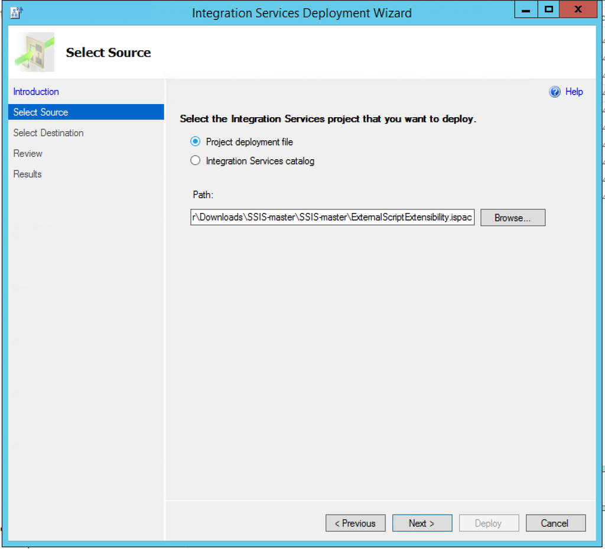

3. Select the desired server

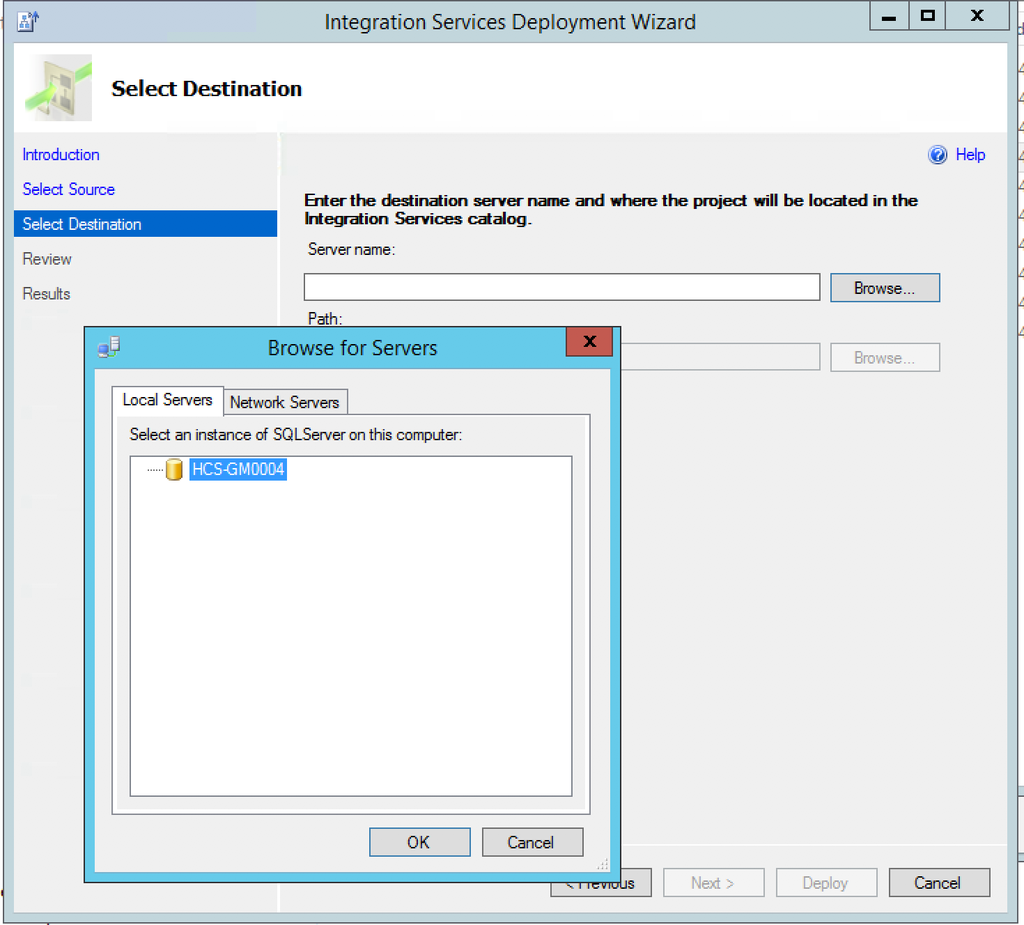

4. Create a new top-level folder `CatalystExtensibility` if it does not exist on the database server

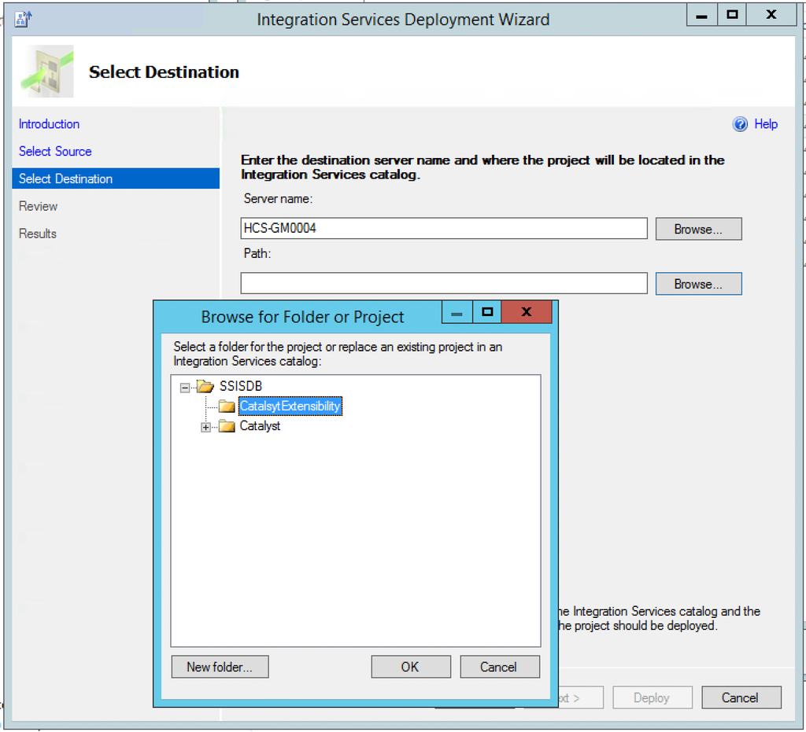

5. Cick `Next` and then `Deploy` and ensure that all results passed.

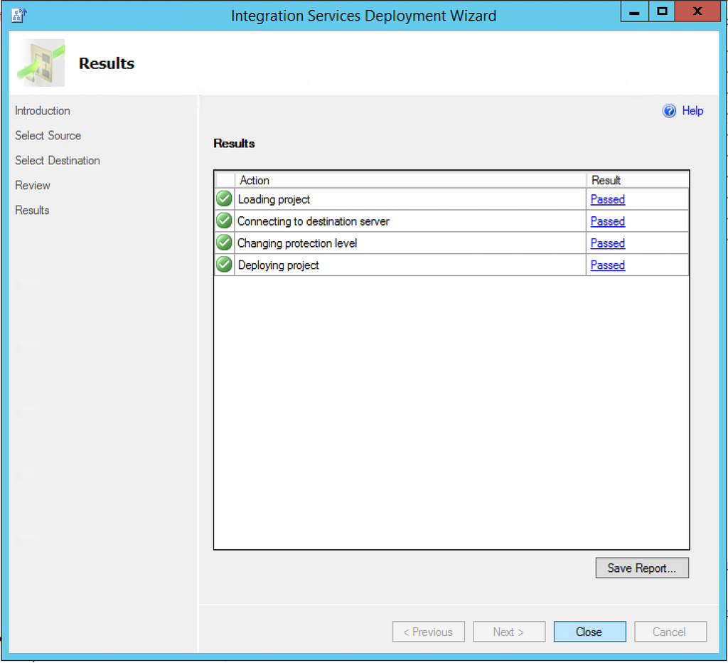

6. Open SSMS and verify that these packages were installed:

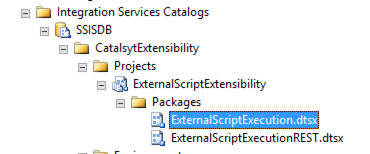

## Permissions and Configuration

1. Determine Identity of EDW_Loader account;
   1. In SSMS, look under Security -> Credentials -> Double click on credential roughly called EDW Loader
   2. Look at and note the account listed in the `Identity` field
2. Configure permissions to allow that same `EDW Loader` user account to read, write, and execute in this directory.
   1. Right click on the folder with the R script
   2. Select `Security` -> `Edit`
   3. Add read, write, and execute permissions to the EDW_Loader account that you identified above
3. Set permissions for SSIS packages installed above. To find existing extensibility points look in: SSMS > Integration Services Catalog > SSISDB > CatalystExtensibility > Projects
   1. Refer to the ETL User Guide for your version of DOS (off of the Catalyst intranet).
   2. Look for `Extensibility` chapter and the section called `Set up permissions for SSIS packages`
   3. Follow instructions to verify permission to allow the `EDW loader` user account to execute.
   4. Don’t forget to `enable proper permissions for the SSIS Database`
4. Under the `Packages` folder, find the `ExternalScriptExecution.dtsx` package, click `Configure` and set the `StagingDirectory` to the working directory (where your R script and rda files live), that was determined above.

## Define Attributes in EDWAdmin

1. Seed three new attribute (`RInterpreterPath`, `ExternalScriptType`, `ExternalRScript`) names into `EDWAdmin.CatalystAdmin.AttributeBASE`. This table can be thought of as a set of keys where values of that key can be set for specific instances of an object elsewhere in `ObjectAttributeBASE`. **Note this SQL can be run as-is. There is no configuration required.**

```sql
IF NOT EXISTS
    (SELECT * FROM EDWAdmin.CatalystAdmin.AttributeBASE WHERE AttributeNM = 'RInterpreterPath')
INSERT INTO EDWAdmin.CatalystAdmin.AttributeBASE (AttributeNM, AttributeDSC)
    VALUES ('RInterpreterPath','Local path to Rscript.exe')
IF NOT EXISTS
    (SELECT * FROM EDWAdmin.CatalystAdmin.AttributeBASE WHERE AttributeNM = 'ExternalScriptType')
INSERT INTO EDWAdmin.CatalystAdmin.AttributeBASE (AttributeNM, AttributeDSC)
    VALUES ('ExternalScriptType','R or Python')
IF NOT EXISTS
    (SELECT * FROM EDWAdmin.CatalystAdmin.AttributeBASE WHERE AttributeNM = 'ExternalRScript')
INSERT INTO EDWAdmin.CatalystAdmin.AttributeBASE (AttributeNM, AttributeDSC)
    VALUES ('ExternalRScript','R script that contains functions')
```

2. Verify that the new Attribute name keys exist in EDWAdmin.

```sql
SELECT [AttributeID]
      ,[AttributeNM]
      ,[AttributeDSC]
  FROM [EDWAdmin].[CatalystAdmin].[AttributeBASE]
WHERE AttributeNM IN ('RInterpreterPath', 'ExternalScriptType', 'ExternalRScript')
```

## Create an Extensibility Point for Each Data Mart

Seed `EDWAdmin.CatalystAdmin.ETLEngineConfigurationBASE` with these values. SQL insert statement is below.

[output not shown]

Note: to get proper visibility into failures, RunInAsyncModeFLG and FailsBatchFLG **must** be set as specified.

The following SQL template needs only a single adjustment of the *DataMartID* before running. This is the DataMartID associated with the SAM where extensibility is being configured.

```sql
INSERT INTO EDWAdmin.CatalystAdmin.ETLEngineConfigurationBASE
(
    ExtensionPointNM, DatamartID, SSISPackagePathOrSPToExecuteTXT,
    IsSSISPackageFLG, ExtensionOwnerNM,
    RunInAsynchModeFLG, Use32BitRuntimeFLG,
    ExecutionOrderNBR, ActiveFLG, RequiredParametersTXT,
    FailsBatchFLG
)
VALUES
(
    'OnPostStageToProdLoad', <DATA_MART_ID>, '\SSISDB\CatalystExtensibility\ExternalScriptExtensibility\ExternalScriptExecution.dtsx',
    1, 'Health Catalyst', 0, 0, 1, 1, 'BatchID, TableID', 1
)
```

Update your `DataMartID` and verify insertion using this SQL template:

```sql
SELECT * FROM EDWAdmin.CatalystAdmin.ETLEngineConfigurationBASE
WHERE DataMartID = <DATA_MART_ID>;
```

## Repeatable Steps For Each Destination Entity

Before proceeding to this step, ensure that your ML script runs on it’s own outside the extensibility point workflow. In otherwords, run it in PowerShell via `RScript.exe file.R` . Then, modify this example, adding in your R script at the end.

```r
# Move to working directory
setwd("C:/Users/levi.thatcher/Downloads") # --> Change to shared folder on ETL server <--

library(methods) # required if using healthcare.ai <v2.0, along with any other libraries you need

# Your R code below...
```

Some deployment best practices for your *R script* (which will be inserted into SQL Server):

1. Use functions from packages, if possible. Long R scripts are extremely hard to debug
2. Outside of your R script’s SQL query, switch to double quotes (`""`) instead of single quotes (`''`). *Why?*
- Helps with insertion into database
- Is [recommended](https://stackoverflow.com/a/20572492) by R community
- *Note:* if you need single quotes, before inserting into EDWAdmin, escape them by [using two single quotes](https://stackoverflow.com/a/1586588), like (`''Bob''`)

Once modified, copy the example into the SQL template below, so it is stored *in* the `ExternalRScript` field in ObjectAttributeBASE

- Seed the following new destination entity attribute values into `EDWAdmin.CatalystAdmin.ObjectAttributeBASE` using the SQL template below. Be sure to adjust the values of the TableID ( = **Destination** Entity of R output), as well as R.exe path and RScript.

```sql
INSERT INTO EDWAdmin.CatalystAdmin.ObjectAttributeBASE
    (ObjectID,ObjectTypeCD,AttributeNM,AttributeTypeCD,AttributeValueTXT)
VALUES
    (<TableID>,'Table','RInterpreterPath','string','C:\Program Files\R\R-3.X.X\bin\Rscript.exe')
INSERT INTO EDWAdmin.CatalystAdmin.ObjectAttributeBASE
    (ObjectID,ObjectTypeCD,AttributeNM,AttributeTypeCD,AttributeValueTXT)
VALUES
    (<TableID>,'Table','ExternalScriptType','string','R')
INSERT INTO EDWAdmin.CatalystAdmin.ObjectAttributeBASE
    (ObjectID,ObjectTypeCD,AttributeNM,AttributeTypeCD,AttributeValueLongTXT)
VALUES
    (<TableID>,'Table','ExternalRScript','longstring','<ENTIRE_CONTENTS_OF_MODIFIED_EXAMPLE>')
```

Verify insertion using this SQL template (edit your `TableID`):

```sql
SELECT * FROM CatalystAdmin.ObjectAttributeBASE WHERE ObjectID = <TableID>
```

## Subject Area Mart (SAM) Configuration

From the perspective of SAMD, the R step is just another SAM binding. It must be configured to run in the proper place in the chain, as SAMs are loaded serially. Think about these dependencies in particular:

- Which table must finish loading before the R Script can run?
- Which table will the R script write to?
- Which table will begin loading after the R script is done writing to the database?

If you haven’t already, follow these steps in Subject Area Mart Designer (SAMD) to configure your SAM for typical predictive model extensibility, where SAMD is being used as part of the model deployment infrastructure:

- Think of the R script as the SAM binding and the output table as the SAM entity. The *source* entity for the extensibility point should be the entity that serves as the dataset the R scripts pulls from. The *destination* entity for the extensibility point should be the entity that the R script populates/outputs to
- Verify that the output binding/entity is set up and tracked in metadata via [these instructions](https://docs.healthcare.ai/articles/site_only/deploy_model.html).
  - This initial metadata entry is essential to being able to reference the R output table in other SAM bindings
  - Create a binding (and entity) in the SAM to handle additional transformation of the model output, if desired. This might include limiting predictions to the most recent predictions that we appended to the output table

## Verify that your Extensibility point is working

1. If it doesn’t harm ongoing ETL, in [EDW Console](http://127.0.0.1/Atlas) create a SAMD batch to run the binding that the R script depends on (and turn on diagnostic logging).
2. Run the batch
3. Verify that a log was created with output from the user script.
4. Delete the logs that were created.
5. At this point the underlying script and its associated environment and libraries have been verified. Congrats on deploying!
6. If you’re putting these predictions in a health system user interface, wait a period for verification of in-production predictions.
   - If you’re predicting 30-day readmissions, it’s wise to wait >30 days to verify that your predictions are accurate.

## Fixing issues

At this point, when you run your SAM, your R script should run the model and append new rows to the destination table. If that doesn’t happen, see these tips.

### Gotchas

- In the R script on Windows paths must use forward slashes `/` because R interprets backslashes as escape characters.
- In the R script, outside of the SQL statement, there must be no single quotes. They must all be double `"` quotes.

### Debugging tips (in order)

1. Make sure you turn on Diagnostic Logging in EDW Console and look for helpful messages in entries with `ExternalScriptExecution`, `Extension` and `OnPostStageToProdLoad`
2. Look in Integration Services Catalogs -> SSISDB -> Catalyst Extensibility and right click on the `ExternalScriptExecution` package and click on Reports -> … Standard Executions

### Common fixes

- When running a batch, if predictions aren’t made and you see this error in EDW Console

  ```
  The SELECT permission was denied on the object 'operations', database 'SSISDB'
  ```

  Then, you must add a permission in SSMS by executing this query, **where edw_loader is changed to your specific loader account**:

  ```sql
  USE SSISDB;
  GRANT SELECT ON internal.operations TO [HQCATALYST\edw_loader];
  GO
  ```